# PPOL 670 Project Showcase

Ivy Deng, Erich Denk, and Ann Marie Stringer

4/29/2019

# **Problem Statement and Background**

- HIV still a problem in the US today more than a million americans live with hiv (CDC)
- No known cure to HIV, only ARV
- HIV disproportionately affects historically marginalized communities
  - MSM population
  - Injection Drug Users
  - Black population
  - Sex workers
- Two prevention methods - both cotroversial/stigmatized
  1. Syringe Services Programs (SSPs)/ Syringe Exchange Programs (SEPs)
  2. Pre-exposure prophylaxis (PrEP)

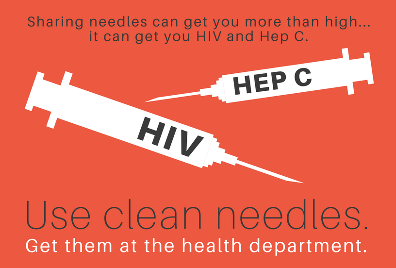

Retrieved from: http://www.buffalotracehealth.com/syringe-access-exchange-program/

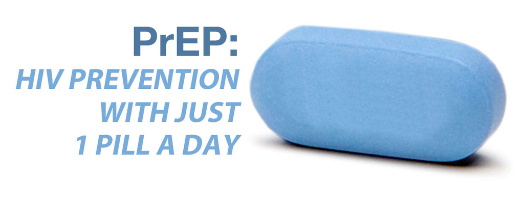

Retrieved from: http://www.araratpharmacy.com/PrEP-HIV-Prevention.html

# **Problem Statement and Background**

*Trends that brought our research question about*

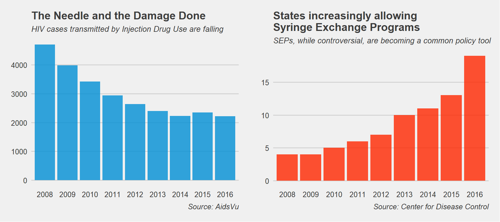

# **Problem Statement and Background (cont.)**

*Trends that brought our research question about*

[figure not shown]

Retrieved from: https://www.hiv.gov/blog/prep-prescriptions-rise-more-work-remains

# **Aim**

> Build a dashboard that walks policy makers and key stakeholders through the unmet need of these two prevention methods (PrEP and SSP). And, for the states that do allow SSPs, can we predict when they will allow them using new diagnoses data?

# **Approach and Design**

- Three main data sources
  1. AidsVu
  2. Center for Disease Control and Prevention State Laws
  3. NASEN SSP locations

# **Approach and Design (cont.)**

- Our original goal – countywide incidence - yearly incidence data not available
- Time series at state level doesn’t really show visual change in mapping - not really impactful.
- The methods we did use..
  - Web scraping (just NASEN)
  - Data Wrangling
  - Data Visualization
  - Mapping
  - Machine Learning
  - Shiny

# **Methods and Tools**

- Dplyr and the **tidyverse**
- The Shiny App
- Urban Maps
- Caret
- ggiraph
- ggplot2

# **Results**

- The shiny app dashboard. Combines a number of efforts together
  - Our [dashboard](https://annmarie.shinyapps.io/Shiny-Apps/)
  - [(backup link)](https://ivy-deng.shinyapps.io/Shiny-Apps/)

Some findings

- PReP usage does not match the need for most states - mapping provides clear visualization of which states in particular
  - Unmet PrEP Demand in states such as Texas, Louisiana, Georgia, and Florida. California, Texas, and Florida show a decreasing trend of number of PrEP users overtime.
  - Southern states in general have more cases of HIV new diagnosis than other regions. However, there are fewer users of PrEP in those states compared to other regions.
- The states with highest unmet need for SSP do not have legislation in place to legalize SSPs
  - Especially: TX, FL, GA, PA
  - West and Northeast regions tend to be more likely to have legislation and lower unmet need, South least likely.

# **Results**

The second (and less successful) effort: Our supervised machine learning results

- Random regression trees
- knn
- random forests

Extremely good at predicting which state-years would *not* allow Syringe Exchange Programs, but not very good at predicting those that do.

Random Forest with extratrees and mtry = 34 was the best model. In that model, here is the relative importance

# **Results**

[interactive chart not shown]

# **Lessons Learned**

- Be flexible! Try to let your preconcieved notions go
- Opportunity to learn about a new topic
- [urbnmapr] package! Perfect for mapping geospatial data.
- Shiny app. Efficient way to display data in various forms and let audience interact with data.

# **Conclusions**

- States with a high HIV prevalence/incidence should invest more resources in supporting and promoting HIV prevention programs (PrEP and SSPs)

# **Thanks!**

- Any questions?